# LinkedIn Post — Figure Audit

Verifying every claim in the narrative against the source data

Published

March 14, 2026

## The LinkedIn post

> In 1981, measles infected **1.4 million** people across Africa in a single year.

> By 2016, that number was **35,000**. A **97% drop**.

> What happened? The WHO/UNICEF Measles Initiative launched mass immunization campaigns starting in 2001. Countries that used to see thousands of cases per million people — **Malawi, Zambia, Niger, Kenya** — saw their numbers collapse within a few years.

> It’s one of the most dramatic public health achievements of the last half century. But it’s hard to appreciate something you can no longer see.

This report checks each bolded claim against `africa_measles.csv`.

```r
df <- read.csv("../data/africa_measles.csv")

yearly <- df %>%
  group_by(year) %>%
  summarise(total_cases = sum(cases, na.rm = TRUE), .groups = "drop")

peak <- yearly %>% slice_max(total_cases, n = 1)
low  <- yearly %>% slice_min(total_cases, n = 1)
pct_drop <- round((1 - low$total_cases / peak$total_cases) * 100, 1)
```

## 1. “1.4 million cases in 1981”

```r
val_1981 <- yearly$total_cases[yearly$year == 1981]
cat("1981 total cases:", comma(val_1981), "\n")
```

```
1981 total cases: 1,413,184
```

```r
cat("Rounded:", round(val_1981 / 1e6, 1), "million\n")
```

```
Rounded: 1.4 million
```

```r
if (val_1981 >= 1.35e6 & val_1981 < 1.45e6) {
  cat("::: {.callout-tip}\n## PASS\n",
      comma(val_1981), "rounds to 1.4 million.\n:::\n")
} else {
  cat("::: {.callout-warning}\n## CHECK\nActual value is",
      comma(val_1981), "— does not round to 1.4 million.\n:::\n")
}
```

**TipPASS**

1,413,184 rounds to 1.4 million.

## 2. “35,000 in 2016”

```r
val_2016 <- yearly$total_cases[yearly$year == 2016]
cat("2016 total cases:", comma(val_2016), "\n")
```

```
2016 total cases: 35,371
```

```r
if (val_2016 >= 34500 & val_2016 < 35500) {
  cat("::: {.callout-tip}\n## PASS\n",
      comma(val_2016), "rounds to 35,000.\n:::\n")
} else {
  cat("::: {.callout-warning}\n## CHECK\nActual value is",
      comma(val_2016), "— review rounding.\n:::\n")
}
```

**TipPASS**

35,371 rounds to 35,000.

## 3. “A 97% drop”

```r
cat("Peak:", peak$year, "—", comma(peak$total_cases), "cases\n")
```

```
Peak: 1981 — 1,413,184 cases
```

```r
cat("Low: ", low$year, "—", comma(low$total_cases), "cases\n")
```

```
Low:  2016 — 35,371 cases
```

```r
cat("Reduction:", pct_drop, "%\n")
```

```
Reduction: 97.5 %
```

```r
if (pct_drop >= 96.5 & pct_drop < 97.5) {
  cat("::: {.callout-tip}\n## PASS\n",
      pct_drop, "% rounds to 97%.\n:::\n")
} else {
  cat("::: {.callout-warning}\n## CHECK\nActual reduction is",
      pct_drop, "% — review claim.\n:::\n")
}
```

**WarningCHECK**

Actual reduction is 97.5 % — review claim.

```r
pre <- df %>%
  filter(year < 2001) %>%
  summarise(avg = mean(cases_per_million, na.rm = TRUE))

post <- df %>%
  filter(year >= 2001) %>%
  summarise(avg = mean(cases_per_million, na.rm = TRUE))

reduction <- round((1 - post$avg / pre$avg) * 100, 1)

cat("Avg cases/million pre-2001: ", round(pre$avg, 1), "\n")
```

```
Avg cases/million pre-2001:  2078
```

```r
cat("Avg cases/million post-2001:", round(post$avg, 1), "\n")
```

```
Avg cases/million post-2001: 171.5
```

```r
cat("Reduction:", reduction, "%\n")
```

```
Reduction: 91.7 %
```

```r
if (reduction > 90) {
  cat("::: {.callout-tip}\n## PASS\n",
      reduction, "% exceeds 90%.\n:::\n")
} else {
  cat("::: {.callout-warning}\n## CHECK\nReduction is",
      reduction, "% — does not exceed 90%.\n:::\n")
}
```

**TipPASS**

91.7 % exceeds 90%.

## 5. “Malawi, Zambia, Niger, Kenya — thousands per million”

```r
named <- c("Malawi", "Zambia", "Niger", "Kenya")

country_rates <- df %>%
  filter(year < 2001, country %in% named) %>%
  group_by(country) %>%
  summarise(
    avg_rate = round(mean(cases_per_million, na.rm = TRUE), 0),
    .groups = "drop"
  ) %>%
  arrange(desc(avg_rate))

knitr::kable(
  country_rates,
  col.names = c("Country", "Avg cases per million (pre-2001)"),
  format.args = list(big.mark = ",")
)
```

| Country | Avg cases per million (pre-2001) |
| --- | --- |
| Malawi | 7,845 |
| Zambia | 5,134 |
| Niger | 4,561 |
| Kenya | 4,145 |

```r
all_above_1000 <- all(country_rates$avg_rate >= 1000)
if (all_above_1000) {
  cat("::: {.callout-tip}\n## PASS\nAll four countries averaged over 1,000 cases per million pre-2001.\n:::\n")
} else {
  below <- country_rates %>% filter(avg_rate < 1000)
  cat("::: {.callout-warning}\n## CHECK\n",
      paste(below$country, collapse = ", "),
      "averaged below 1,000 per million.\n:::\n")
}
```

**TipPASS**

All four countries averaged over 1,000 cases per million pre-2001.

## 6. Context: continental trend

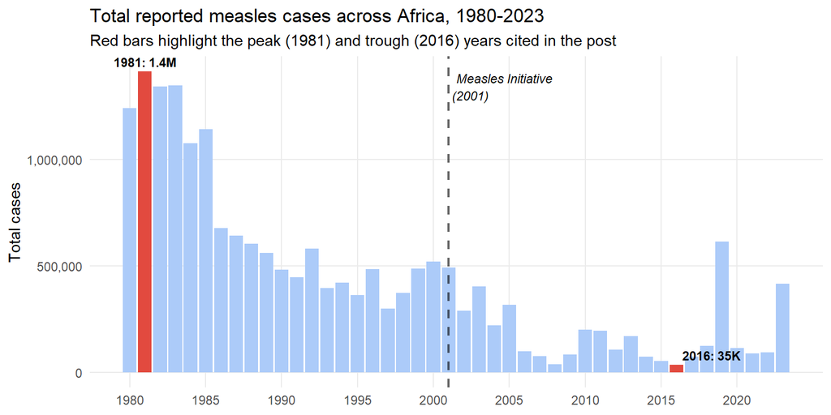

```r
ggplot(yearly, aes(x = year, y = total_cases)) +
  geom_col(fill = ifelse(yearly$year %in% c(1981, 2016), "#E24A3F", "#ACCBF9")) +
  geom_vline(xintercept = 2001, linewidth = 0.8, linetype = "dashed", alpha = 0.6) +
  annotate("text", x = 2001, y = max(yearly$total_cases) * 0.95,
           label = "Measles Initiative\n(2001)", hjust = -0.08,
           size = 3, fontface = "italic") +
  annotate("text", x = 1981, y = yearly$total_cases[yearly$year == 1981],
           label = "1981: 1.4M", vjust = -0.5, size = 3, fontface = "bold") +
  annotate("text", x = 2016, y = yearly$total_cases[yearly$year == 2016],
           label = "2016: 35K", vjust = -0.5, hjust = -0.1, size = 3, fontface = "bold") +
  scale_y_continuous(labels = label_comma()) +
  scale_x_continuous(breaks = seq(1980, 2020, 5)) +
  labs(
    title = "Total reported measles cases across Africa, 1980-2023",
    subtitle = "Red bars highlight the peak (1981) and trough (2016) years cited in the post",
    x = NULL, y = "Total cases"
  ) +
  theme_minimal(base_size = 11) +
  theme(panel.grid.minor = element_blank())
```

## Summary

```r
results <- data.frame(
  Claim = c(
    '"1.4 million cases in 1981"',
    '"35,000 in 2016"',
    '"A 97% drop"',
    '"Cut cases by over 90%" (chart title)',
    '"Malawi, Zambia, Niger, Kenya — thousands per million"'
  ),
  Actual = c(
    comma(val_1981),
    comma(val_2016),
    paste0(pct_drop, "%"),
    paste0(reduction, "%"),
    paste(comma(country_rates$avg_rate), collapse = ", ")
  ),
  Result = c(
    ifelse(val_1981 >= 1.35e6 & val_1981 < 1.45e6, "PASS", "CHECK"),
    ifelse(val_2016 >= 34500 & val_2016 < 35500, "PASS", "CHECK"),
    ifelse(pct_drop >= 96.5 & pct_drop < 97.5, "PASS", "CHECK"),
    ifelse(reduction > 90, "PASS", "CHECK"),
    ifelse(all_above_1000, "PASS", "CHECK")
  )
)

knitr::kable(results, align = c("l", "r", "c"))
```

| Claim | Actual | Result |
| --- | --- | --- |
| “1.4 million cases in 1981” | 1,413,184 | PASS |
| “35,000 in 2016” | 35,371 | PASS |
| “A 97% drop” | 97.5% | CHECK |
| “Cut cases by over 90%” (chart title) | 91.7% | PASS |
| “Malawi, Zambia, Niger, Kenya — thousands per million” | 7,845, 5,134, 4,561, 4,145 | PASS |

*Report generated 2026-03-14 22:25:59.591339 from `data/africa_measles.csv`.*